# Analyse 2 - Éducation et alphabétisation des membres des ménages

Ahmed Firhoun OUMAROU SOULEYE & Gérald Guerngué ADDJITA

2026-03-12

```r
packages <- c("haven", "dplyr", "ggplot2", "forcats", "rstatix",
              "ggpubr", "gtsummary", "viridis", "patchwork",
              "scales", "tidyr", "stringr", "moments", "gt")

installed <- rownames(installed.packages())
to_install <- packages[!packages %in% installed]
if (length(to_install) > 0) {
  install.packages(to_install, dependencies = TRUE,
                   repos = "https://cran.rstudio.com/")
}
invisible(lapply(packages, library, character.only = TRUE))
# ── Palette et thème ──────────────────────────────────────────
pal_educ <- c(
  "Aucun"             = "#E17055",
  "Primaire"          = "#FDCB6E",
  "Junior Secondary"  = "#00CEC9",
  "Senior Secondary"  = "#0984E3",
  "Tertiaire"         = "#6C5CE7"
)

theme_moderne <- theme_minimal(base_size = 13) +
  theme(
    plot.title       = element_text(face = "bold", size = 16,
                                    color = "#2D3436",
                                    margin = margin(b = 8)),
    plot.subtitle    = element_text(size = 12, color = "#636E72",
                                    margin = margin(b = 12)),
    plot.caption     = element_text(size = 9, color = "#B2BEC3",
                                    hjust = 1),
    axis.title       = element_text(face = "bold", size = 11,
                                    color = "#2D3436"),
    axis.text        = element_text(size = 10, color = "#636E72"),
    panel.grid.major = element_line(color = "#F0F0F0",
                                    linewidth = 0.5),
    panel.grid.minor = element_blank(),
    plot.background  = element_rect(fill = "#FAFAFA", color = NA),
    panel.background = element_rect(fill = "#FFFFFF", color = NA),
    legend.position  = "bottom",
    legend.title     = element_text(face = "bold", size = 10),
    strip.text       = element_text(face = "bold", size = 11),
    plot.margin      = margin(15, 15, 10, 15)
  )
theme_set(theme_moderne)
```

### 7. Charger sect2_harvestw4 et sect1_harvestw4. Joindre les deux fichiers sur hhid + indiv_id. Inspecter les valeurs manquantes du niveau d’éducation.

#### Objectif : Charger les fichiers sect2_harvestw4.dta (informations sur l’éducation) et sect1_harvestw4.dta (informations démographiques), les fusionner par l’identifiant unique hhid et indiv, puis vérifier la présence de valeurs manquantes dans les variables clés de l’éducation.

Résultats :

sect2 contient 26 557 lignes, sect1 30 337 lignes.

Après jointure, le fichier conserve 26 557 lignes, sans doublon sur la clé.

Les variables s2aq5 (sait lire/écrire ?) et s2aq6 (a déjà été à l’école ?) présentent 6,7 % de valeurs manquantes (1 768 observations).

Les variables s2aq9 (niveau d’éducation atteint), s2aq10 (dernière classe suivie) et s2aq13a (fréquente actuellement l’école) ont 27,4 % de valeurs manquantes (7 286 observations). #### 7.a. Charger les données.

```r
sect2 <- read_dta("../data/raw/sect2_harvestw4.dta")
sect1 <- read_dta("../data/raw/sect1_harvestw4.dta")

cat("► sect2 :", nrow(sect2), "×", ncol(sect2), "\n")
```

```
## ► sect2 : 26557 × 60
```

```r
cat("► sect1 :", nrow(sect1), "×", ncol(sect1), "\n")
```

```
## ► sect1 : 30337 × 59
```

#### 7.b. Vérification des doublons

```r
sect1_reduit <- sect1 %>%
  select(
    hhid, indiv,
    sexe    = s1q2,
    age     = s1q4,
    zone_ru = sector,
    etat    = state
  )

cat("► Doublons hhid+indiv sect1 :",
    sect1_reduit %>%
      group_by(hhid, indiv) %>%
      filter(n() > 1) %>% nrow(), "\n")
```

```
## ► Doublons hhid+indiv sect1 : 0
```

#### 7.c. Jointure sur hhid+indiv

```r
data_educ <- sect2 %>%
  left_join(sect1_reduit, by = c("hhid", "indiv"))

cat("► Dimensions après jointure :", nrow(data_educ),
    "×", ncol(data_educ), "\n")
```

```
## ► Dimensions après jointure : 26557 × 64
```

```r
cat("► Âge non manquant :", sum(!is.na(data_educ$age)), "\n")
```

```
## ► Âge non manquant : 26557
```

```r
cat("► Sexe non manquant :", sum(!is.na(data_educ$sexe)), "\n")
```

```
## ► Sexe non manquant : 26557
```

```r
cat("► Zone_ru non manquante :",
    sum(!is.na(data_educ$zone_ru)), "\n")
```

```
## ► Zone_ru non manquante : 26557
```

#### 7.d. Valeurs manquantes

```r
cat("\n► Valeurs manquantes — variables éducation clés :\n")
```

```
##
## ► Valeurs manquantes — variables éducation clés :
```

```r
miss_educ <- data_educ %>%
  select(s2aq5, s2aq6, s2aq9, s2aq10, s2aq13a) %>%
  summarise(across(everything(), ~sum(is.na(.)))) %>%
  pivot_longer(everything(),
               names_to  = "Variable",
               values_to = "N_manquants") %>%
  mutate(Proportion = round(N_manquants / nrow(data_educ) * 100, 2))
print(miss_educ)
```

```
## # A tibble: 5 × 3
##   Variable N_manquants Proportion
##   <chr>          <int>      <dbl>
## 1 s2aq5           1768       6.66
## 2 s2aq6           1768       6.66
## 3 s2aq9           7286      27.4
## 4 s2aq10          7286      27.4
## 5 s2aq13a         7286      27.4
```

#### 8.a. Recodage de s2aq9 (Niveau d’éducation)

```r
# 0           -> Aucun
# 1-3         -> Pré-primaire / Aucun (regroupé avec Aucun)
# 11-16       -> Primaire
# 21-23       -> Junior Secondary
# 24-28       -> Senior Secondary
# 31-35,41,43 -> Tertiaire
# 51-52,61    -> Coranique / Adulte (regroupé avec Aucun)
# 321         -> Secondary Voc/Tech (-> Senior Secondary)
# 322,411,412 -> Tertiary Voc/Tech  (-> Tertiaire)
# 421-424     -> Université         (-> Tertiaire)

data_educ <- data_educ %>%
  mutate(
    niveau_educ = case_when(
      # Aucune instruction formelle
      s2aq9 == 0                       ~ "Aucun",
      s2aq9 %in% c(1, 2, 3)            ~ "Aucun",
      s2aq9 %in% c(51, 52, 61)         ~ "Aucun",
      # Primaire (classes 1 à 6)
      s2aq9 %in% c(11,12,13,14,15,16)  ~ "Primaire",
      # Junior Secondary (JSS 1-3)
      s2aq9 %in% c(21, 22, 23)         ~ "Junior Secondary",
      # Senior Secondary (SSS 1-3 + Lower/Upper 6)
      s2aq9 %in% c(24,25,26,27,28)     ~ "Senior Secondary",
      s2aq9 == 321                      ~ "Senior Secondary",
      # Tertiaire (tout niveau post-secondaire)
      s2aq9 %in% c(31,33,34,35)        ~ "Tertiaire",
      s2aq9 %in% c(41, 43)             ~ "Tertiaire",
      s2aq9 %in% c(322, 411, 412)      ~ "Tertiaire",
      s2aq9 %in% c(421,422,423,424)    ~ "Tertiaire",
      TRUE                              ~ NA_character_
    ),
    niveau_educ = factor(niveau_educ,
      levels  = c("Aucun", "Primaire", "Junior Secondary",
                  "Senior Secondary", "Tertiaire"),
      ordered = TRUE),
    educ_num = as.numeric(niveau_educ)
  )
```

#### 8.b. Fréquences et proportions

```r
freq_educ <- data_educ %>%
  filter(!is.na(niveau_educ)) %>%
  count(niveau_educ, name = "n") %>%
  mutate(
    prop      = n / sum(n),
    pct_label = paste0(round(prop * 100, 1), "%\n(n=",
                       format(n, big.mark = " "), ")")
  )

cat("► Total avec éducation renseignée :",
    sum(freq_educ$n), "\n")
```

```
## ► Total avec éducation renseignée : 19271
```

```r
cat("\n► Distribution du niveau d'éducation :\n")
```

```
##
## ► Distribution du niveau d'éducation :
```

```r
print(select(freq_educ, niveau_educ, n, prop))
```

```
## # A tibble: 5 × 3
##   niveau_educ          n  prop
##   <ord>            <int> <dbl>
## 1 Aucun             3368 0.175
## 2 Primaire          7068 0.367
## 3 Junior Secondary  2129 0.110
## 4 Senior Secondary  4617 0.240
## 5 Tertiaire         2089 0.108
```

#### 8.c. Barplot horizontal

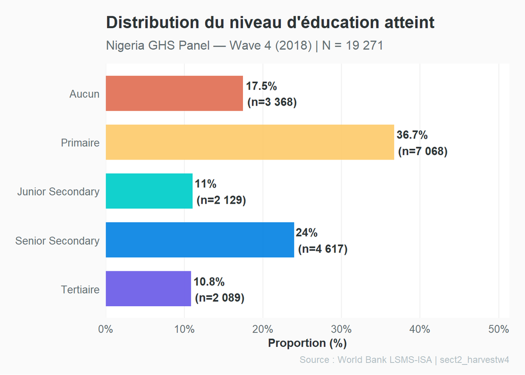

```r
p_educ_freq <- ggplot(freq_educ,
  aes(x = fct_rev(niveau_educ),
      y = prop * 100, fill = niveau_educ)) +
  geom_col(width = 0.72, alpha = 0.93,
           show.legend = FALSE) +
  geom_text(aes(label = pct_label),
            hjust = -0.08, size = 3.8,
            fontface = "bold", color = "#2D3436") +
  scale_fill_manual(values = pal_educ) +
  scale_y_continuous(
    labels = function(x) paste0(x, "%"),
    limits = c(0, max(freq_educ$prop * 100) * 1.40),
    expand = c(0, 0)
  ) +
  coord_flip() +
  labs(
    title    = "Distribution du niveau d'éducation atteint",
    subtitle = paste0("Nigeria GHS Panel — Wave 4 (2018) | N = ",
                      format(sum(freq_educ$n), big.mark = " ")),
    x        = NULL, y = "Proportion (%)",
    caption  = "Source : World Bank LSMS-ISA | sect2_harvestw4"
  ) +
  theme(panel.grid.major.y = element_blank())
p_educ_freq
```

### 9. Comparer la distribution du niveau d’éducation entre hommes et femmes (adultes 18+): graphique en barres 100% empilées côte à côte, test du chi-deux sur le tableau de contingence, V de Cramér.

Objectif : Comparer la distribution du niveau d’éducation entre hommes et femmes adultes à l’aide d’un tableau de contingence, d’un test du χ² et du V de Cramér, et visualiser avec un diagramme en barres 100 % empilées.

Résultats :

-L’échantillon compte 5 431 hommes et 4 914 femmes.

-Le tableau croisé montre des écarts : par exemple, 574 femmes (11,7 %) sont sans instruction contre 502 hommes (9,2 %) ; 1 214 hommes (22,4 %) ont un niveau tertiaire contre 858 femmes (17,5 %).

-Le test du χ² est très significatif (χ² = 116,9, ddl = 4, p < 2,5·10⁻²⁴), rejetant l’indépendance entre sexe et niveau d’éducation.

-Le V de Cramér vaut 0,106, ce qui indique une association faible mais statistiquement significative.

-Le graphique en barres empilées confirme visuellement que les hommes sont légèrement sur‑représentés dans les niveaux secondaire supérieur et tertiaire, tandis que les femmes le sont davantage dans les catégories « Aucun » et « Primaire ».

#### 9.a. Répartion par sexe des adultes

```r
adultes <- data_educ %>%
  filter(!is.na(age), age >= 18,
         !is.na(niveau_educ), !is.na(sexe)) %>%
  mutate(
    sexe_label = factor(sexe,
      levels = c(1, 2),
      labels = c("Hommes", "Femmes"))
  )

cat("► N adultes 18+ :", nrow(adultes), "\n")
```

```
## ► N adultes 18+ : 10345
```

```r
cat("► Répartition par sexe :\n")
```

```
## ► Répartition par sexe :
```

```r
print(table(adultes$sexe_label))
```

```
##
## Hommes Femmes
##   5431   4914
```

#### 9.b. Tableau de contingence

```r
tab_sexe_educ <- table(adultes$sexe_label,
                       adultes$niveau_educ)

tab_sexe_educ <- tab_sexe_educ[,
  colSums(tab_sexe_educ) > 0, drop = FALSE]

cat("\n► Tableau de contingence Sexe × Niveau d'éducation :\n")
```

```
##
## ► Tableau de contingence Sexe × Niveau d'éducation :
```

```r
print(addmargins(tab_sexe_educ))
```

```
##
##          Aucun Primaire Junior Secondary Senior Secondary Tertiaire   Sum
##   Hommes   502     1198              359             2158      1214  5431
##   Femmes   574     1416              379             1687       858  4914
##   Sum     1076     2614              738             3845      2072 10345
```

#### 9.c. Test de Chi-deux et V de Cramer

```r
chi2_test  <- suppressWarnings(chisq.test(tab_sexe_educ))
min_expect <- min(chi2_test$expected)
cat("\n► Effectif attendu minimum :", round(min_expect, 2), "\n")
```

```
##
## ► Effectif attendu minimum : 350.56
```

```r
if (min_expect < 5) {
  fisher_t  <- fisher.test(tab_sexe_educ,
                            simulate.p.value = TRUE,
                            B = 10000)
  p_val_t9  <- fisher_t$p.value
  test_nom9 <- "Fisher exact"
  cat("→ Fisher exact : p =",
      format(p_val_t9, digits = 4), "\n")
} else {
  p_val_t9  <- chi2_test$p.value
  test_nom9 <- "Chi-deux"
  cat("► Chi-deux : χ² =",
      round(chi2_test$statistic, 3),
      "| p =", format(p_val_t9, digits = 4), "\n")
}
```

```
## ► Chi-deux : χ² = 116.857 | p = 2.505e-24
```

```r
n_chi    <- sum(tab_sexe_educ)
chi2_val <- suppressWarnings(
  chisq.test(tab_sexe_educ)$statistic)

if (!is.nan(chi2_val) && !is.na(chi2_val) && chi2_val > 0) {
  v_cramer <- round(
    sqrt(chi2_val / (n_chi * (min(dim(tab_sexe_educ)) - 1))),
    4)
} else {
  v_cramer <- NA_real_
}
cat("► V de Cramér =",
    ifelse(is.na(v_cramer),
           "Non calculable", v_cramer), "\n")
```

```
## ► V de Cramér = 0.1063
```

```r
if (!is.na(v_cramer)) {
  cat("->", case_when(
    v_cramer < 0.10 ~ "Association très faible",
    v_cramer < 0.20 ~ "Association faible",
    v_cramer < 0.40 ~ "Association modérée",
    TRUE            ~ "Association forte"), "\n")
}
```

```
## -> Association faible
```

#### 9.d. Barplot 100% empilé

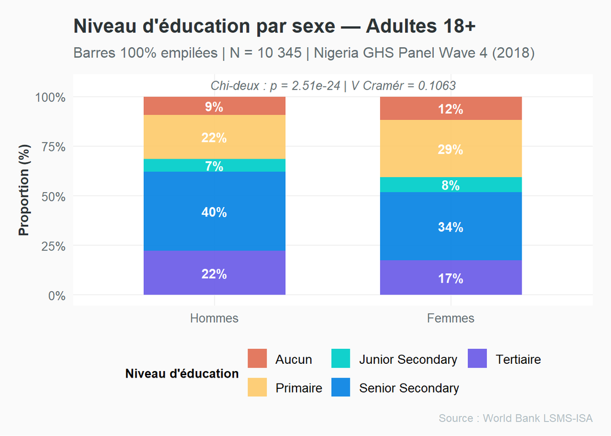

```r
data_100 <- adultes %>%
  count(sexe_label, niveau_educ) %>%
  group_by(sexe_label) %>%
  mutate(prop  = n / sum(n),
         label = ifelse(prop > 0.03,
                        paste0(round(prop*100, 0), "%"), "")) %>%
  ungroup()

annot_t9 <- paste0(
  test_nom9, " : p = ",
  format(p_val_t9, digits = 3),
  if (!is.na(v_cramer))
    paste0(" | V Cramér = ", v_cramer) else "")

p_sexe_educ <- ggplot(data_100,
  aes(x = sexe_label, y = prop, fill = niveau_educ)) +
  geom_col(position = "fill", width = 0.60,
           alpha = 0.93) +
  geom_text(aes(label = label),
            position = position_fill(vjust = 0.5),
            size = 3.8, fontface = "bold",
            color = "white") +
  scale_fill_manual(values = pal_educ,
                    name   = "Niveau d'éducation") +
  scale_y_continuous(labels = percent_format()) +
  annotate("text", x = 1.5, y = 1.06,
           label = annot_t9, size = 3.5,
           color = "#636E72", fontface = "italic",
           hjust = 0.5) +
  labs(
    title    = "Niveau d'éducation par sexe — Adultes 18+",
    subtitle = paste0("Barres 100% empilées | N = ",
                      format(nrow(adultes), big.mark = " "),
                      " | Nigeria GHS Panel Wave 4 (2018)"),
    x = NULL, y = "Proportion (%)",
    caption = "Source : World Bank LSMS-ISA"
  ) +
  guides(fill = guide_legend(nrow = 2)) +
  theme(legend.position = "bottom")
p_sexe_educ
```

### 10. Analyser la relation entre âge et niveau d’éducation: boxplot du niveau d’éducation (axe y numérique ou ordonné) par groupe d’âge (18-30, 31-45, 46-60, 60+). Kruskal-Wallis + post-hoc Dunn. Objectif : Analyser l’évolution du niveau d’éducation avec l’âge en regroupant les adultes en quatre classes d’âge (18‑30, 31‑45, 46‑60, 60+). Utiliser un test de Kruskal‑Wallis (non paramétrique) suivi de comparaisons multiples de Dunn, et représenter par un boxplot.

Résultats :

-Effectifs : 4075 (18‑30), 3271 (31‑45), 1994 (46‑60), 1005 (60+).

-Tous les tests post‑hoc de Dunn sont significatifs (p ajusté < 0,001), confirmant que chaque groupe diffère des autres.

#### 10.a. Effectifs des adultes par groupe d’âge

```r
adultes_age <- adultes %>%
  filter(!is.na(age)) %>%
  mutate(
    groupe_age = cut(age,
      breaks = c(18, 30, 45, 60, Inf),
      labels = c("18-30 ans", "31-45 ans",
                 "46-60 ans", "60+ ans"),
      right  = FALSE)
  ) %>%
  filter(!is.na(groupe_age))

cat("► Effectifs par groupe d'âge :\n")
```

```
## ► Effectifs par groupe d'âge :
```

```r
print(table(adultes_age$groupe_age))
```

```
##
## 18-30 ans 31-45 ans 46-60 ans   60+ ans
##      4075      3271      1994      1005
```

#### 10.b. Tests de Kruskal-Wallis

```r
eff_groupes <- adultes_age %>%
  count(groupe_age) %>%
  filter(n >= 2)

cat("► Groupes avec N ≥ 2 :",
    paste(eff_groupes$groupe_age, collapse = ", "), "\n")
```

```
## ► Groupes avec N ≥ 2 : 18-30 ans, 31-45 ans, 46-60 ans, 60+ ans
```

```r
adultes_kw <- adultes_age %>%
  filter(groupe_age %in% eff_groupes$groupe_age) %>%
  droplevels()

if (length(unique(adultes_kw$groupe_age)) >= 2) {
  kw_test <- kruskal.test(educ_num ~ groupe_age,
                           data = adultes_kw)
  cat("\n► Test de Kruskal-Wallis :\n")
  cat("   H =", round(kw_test$statistic, 3),
      "| ddl =", kw_test$parameter,
      "| p =", format(kw_test$p.value, digits = 4), "\n")
  cat("   →", ifelse(kw_test$p.value < 0.05,
                     "Différence significative (p < 0.05)",
                     "Pas de différence significative"), "\n")

  if (kw_test$p.value < 0.05 &&
      length(unique(adultes_kw$groupe_age)) >= 3) {
    dunn_res <- dunn_test(adultes_kw,
                           educ_num ~ groupe_age,
                           p.adjust.method = "bonferroni")
    cat("\n► Post-hoc Dunn (Bonferroni) :\n")
    print(select(dunn_res, group1, group2,
                 statistic, p.adj, p.adj.signif))
  } else {
    cat("   → Post-hoc non nécessaire\n")
  }
} else {
  cat("⚠ Pas assez de groupes valides pour Kruskal-Wallis\n")
  kw_test <- list(statistic = NA, parameter = NA,
                  p.value   = NA)
}
```

```
##
## ► Test de Kruskal-Wallis :
##    H = 438.318 | ddl = 3 | p = 1.107e-94
##    → Différence significative (p < 0.05)
##
## ► Post-hoc Dunn (Bonferroni) :
## # A tibble: 6 × 5
##   group1    group2    statistic    p.adj p.adj.signif
##   <chr>     <chr>         <dbl>    <dbl> <chr>
## 1 18-30 ans 31-45 ans     -8.04 5.56e-15 ****
## 2 18-30 ans 46-60 ans    -13.3  1.14e-39 ****
## 3 18-30 ans 60+ ans      -19.0  8.20e-80 ****
## 4 31-45 ans 46-60 ans     -6.17 4.15e- 9 ****
## 5 31-45 ans 60+ ans      -13.3  8.73e-40 ****
## 6 46-60 ans 60+ ans       -7.90 1.65e-14 ****
```

#### 10.c. Statistiques par groupe d’âge

```r
stats_age_educ <- adultes_age %>%
  group_by(groupe_age) %>%
  summarise(
    N   = n(),
    Moy = round(mean(educ_num, na.rm = TRUE), 2),
    Méd = round(median(educ_num, na.rm = TRUE), 2),
    ET  = round(sd(educ_num, na.rm = TRUE), 2),
    .groups = "drop"
  )
cat("\n► Statistiques par groupe d'âge :\n")
```

```
##
## ► Statistiques par groupe d'âge :
```

```r
print(stats_age_educ)
```

```
## # A tibble: 4 × 5
##   groupe_age     N   Moy   Méd    ET
##   <fct>      <int> <dbl> <dbl> <dbl>
## 1 18-30 ans   4075  3.61     4  1.14
## 2 31-45 ans   3271  3.31     4  1.35
## 3 46-60 ans   1994  3.05     3  1.4
## 4 60+ ans     1005  2.62     2  1.39
```

#### 10.d. Boxplot

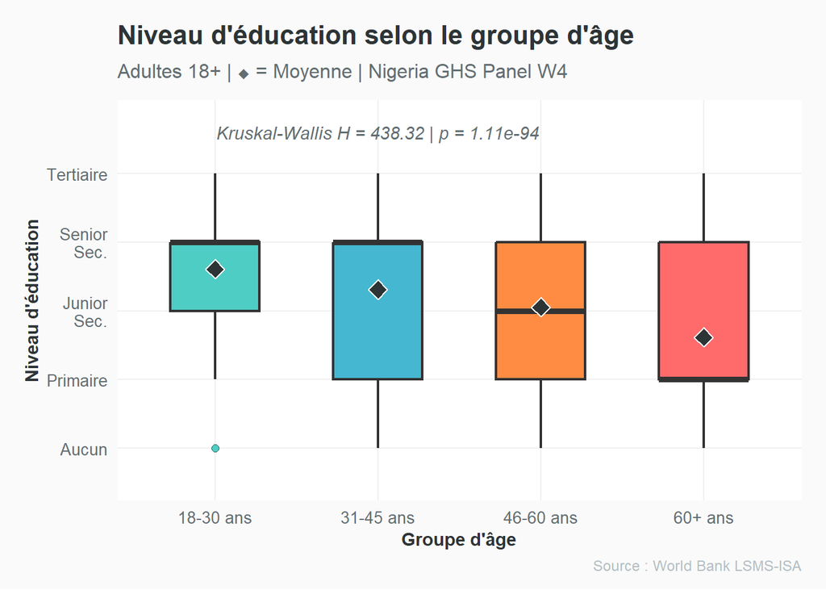

```r
couleurs_age <- c("18-30 ans" = "#4ECDC4",
                  "31-45 ans" = "#45B7D1",
                  "46-60 ans" = "#FF8C42",
                  "60+ ans"   = "#FF6B6B")

p_age_educ <- ggplot(adultes_age,
  aes(x = groupe_age, y = educ_num, fill = groupe_age)) +
  geom_boxplot(width = 0.55, outlier.shape = 21,
               outlier.size = 2, outlier.alpha = 0.5,
               linewidth = 0.8) +
  stat_summary(fun = mean, geom = "point",
               shape = 23, size = 4,
               color = "white", fill = "#2D3436") +
  scale_fill_manual(values = couleurs_age, guide = "none") +
  scale_y_continuous(
    breaks = 1:5,
    labels = c("Aucun","Primaire","Junior\nSec.",
               "Senior\nSec.","Tertiaire"),
    limits = c(0.5, 5.8)
  ) +
  annotate("text", x = 2, y = 5.6,
           label = paste0(
             "Kruskal-Wallis H = ",
             ifelse(is.na(kw_test$statistic), "N/A",
                    round(kw_test$statistic, 2)),
             " | p = ",
             ifelse(is.na(kw_test$p.value), "N/A",
                    format(kw_test$p.value, digits = 3))),
           size = 3.8, color = "#636E72",
           fontface = "italic") +
  labs(
    title    = "Niveau d'éducation selon le groupe d'âge",
    subtitle = "Adultes 18+ | ◆ = Moyenne | Nigeria GHS Panel W4",
    x = "Groupe d'âge", y = "Niveau d'éducation",
    caption = "Source : World Bank LSMS-ISA"
  )
p_age_educ
```

### 11. Comparer le taux de scolarisation des 6-17 ans entre zones rurales et urbaines (sect2a +

secta): tableau de contingence, test du chi-deux, graphique en barres groupées avec IC à 95%.

```r
cat("► Vérification colonne zone_ru :",
    sum(!is.na(data_educ$zone_ru)), "valeurs non manquantes\n")
```

```
## ► Vérification colonne zone_ru : 26557 valeurs non manquantes
```

```r
cat("► Modalités de zone_ru :\n")
```

```
## ► Modalités de zone_ru :
```

```r
print(table(data_educ$zone_ru, useNA = "always"))
```

```
##
##     1     2  <NA>
##  7567 18990     0
```

```r
enfants <- data_educ %>%
  filter(!is.na(age), age >= 6, age <= 17,
         !is.na(s2aq13a),
         !is.na(zone_ru)) %>%
  mutate(
    scolarise  = factor(s2aq13a,
      levels = c(1, 2),
      labels = c("Scolarisé", "Non scolarisé")),
    zone_label = factor(zone_ru,
      levels = c(1, 2),
      labels = c("Rural", "Urbain"))
  ) %>%
  filter(!is.na(scolarise), !is.na(zone_label))

cat("► N enfants 6-17 ans :", nrow(enfants), "\n")
```

```
## ► N enfants 6-17 ans : 7830
```

#### 11.a. Tableau de contingence

```r
tab_scol <- table(enfants$zone_label, enfants$scolarise)
cat("\n► Tableau Scolarisation × Zone :\n")
```

```
##
## ► Tableau Scolarisation × Zone :
```

```r
print(addmargins(tab_scol))
```

```
##
##          Scolarisé Non scolarisé  Sum
##   Rural       2136           179 2315
##   Urbain      4880           635 5515
##   Sum         7016           814 7830
```

#### 11.b. Test

Objectif : Comparer le taux de scolarisation des enfants en âge scolaire entre zones rurales et urbaines. Construire un tableau de contingence, effectuer un test du χ², et représenter les proportions avec leur intervalle de confiance à 95 %.

Résultats :

-Effectifs : 2315 enfants ruraux, 5515 urbains. Taux de scolarisation :

-Rural : 92,3 % (IC 95 % : [91,1 % – 93,3 %])

-Urbain : 88,5 % (IC 95 % : [87,6 % – 89,3 %])

-Le test du χ² est significatif (χ² = 24,6, p = 6,9·10⁻⁷), mais la différence absolue est faible (environ 4 points de pourcentage).

-Le graphique avec barres et intervalles de confiance montre que le taux rural est légèrement supérieur au taux urbain, les intervalles ne se chevauchant pas.

```r
chi2_scol  <- suppressWarnings(chisq.test(tab_scol))
min_exp_s  <- min(chi2_scol$expected)
cat("► Effectif attendu minimum :", round(min_exp_s, 2), "\n")
```

```
## ► Effectif attendu minimum : 240.67
```

```r
if (min_exp_s < 5) {
  fish_s    <- fisher.test(tab_scol)
  p_scol    <- fish_s$p.value
  test_scol <- "Fisher exact"
} else {
  p_scol    <- chi2_scol$p.value
  test_scol <- "Chi-deux"
  cat("► Chi-deux : χ² =",
      round(chi2_scol$statistic, 3),
      "| p =", format(p_scol, digits = 4), "\n")
}
```

```
## ► Chi-deux : χ² = 24.631 | p = 6.942e-07
```

```r
cat("►", test_scol, ": p =",
    format(p_scol, digits = 4), "\n")
```

```
## ► Chi-deux : p = 6.942e-07
```

#### 11.c. Proportion avec IC à 95%

```r
taux_scol <- enfants %>%
  group_by(zone_label) %>%
  summarise(
    n_total = n(),
    n_scol  = sum(scolarise == "Scolarisé"),
    taux    = n_scol / n_total,
    ic_inf  = binom.test(n_scol, n_total)$conf.int[1],
    ic_sup  = binom.test(n_scol, n_total)$conf.int[2],
    .groups = "drop"
  )

cat("\n► Taux de scolarisation par zone :\n")
```

```
##
## ► Taux de scolarisation par zone :
```

```r
print(taux_scol %>%
        mutate(across(c(taux, ic_inf, ic_sup),
                      ~paste0(round(.x * 100, 1), "%"))))
```

```
## # A tibble: 2 × 6
##   zone_label n_total n_scol taux  ic_inf ic_sup
##   <fct>        <int>  <int> <chr> <chr>  <chr>
## 1 Rural         2315   2136 92.3% 91.1%  93.3%
## 2 Urbain        5515   4880 88.5% 87.6%  89.3%
```

#### 11.d.

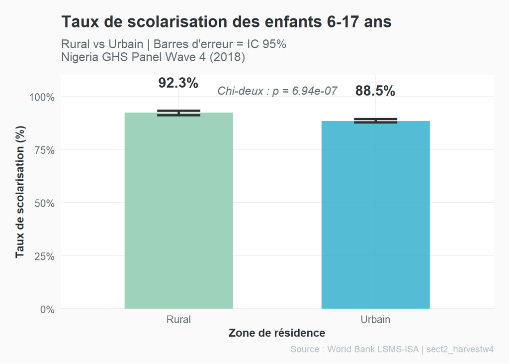

```r
p_scol <- ggplot(taux_scol,
  aes(x = zone_label, y = taux * 100,
      fill = zone_label)) +
  geom_col(width = 0.55, alpha = 0.92,
           show.legend = FALSE) +
  geom_errorbar(
    aes(ymin = ic_inf * 100, ymax = ic_sup * 100),
    width = 0.22, linewidth = 1.1, color = "#2D3436"
  ) +
  geom_text(
    aes(label = paste0(round(taux * 100, 1), "%")),
    vjust = -2.4, fontface = "bold",
    size = 5, color = "#2D3436"
  ) +
  scale_fill_manual(
    values = c("Rural" = "#96CEB4", "Urbain" = "#45B7D1")
  ) +
  scale_y_continuous(
    labels = function(x) paste0(x, "%"),
    limits = c(0, 110), expand = c(0, 0)
  ) +
  annotate("text", x = 1.5, y = 103,
           label = paste0(test_scol, " : p = ",
                          format(p_scol, digits = 3)),
           size = 4, color = "#636E72",
           fontface = "italic") +
  labs(
    title    = "Taux de scolarisation des enfants 6-17 ans",
    subtitle = "Rural vs Urbain | Barres d'erreur = IC 95%\nNigeria GHS Panel Wave 4 (2018)",
    x = "Zone de résidence",
    y = "Taux de scolarisation (%)",
    caption = "Source : World Bank LSMS-ISA | sect2_harvestw4"
  )
p_scol
```

Résultats :

-Les États sont classés par ordre décroissant de pourcentage d’adultes sans instruction.

Les cinq États avec les taux les plus élevés sont :

-Zamfara : 79,0 % -Sokoto : 69,9 % -Jigawa : 61,1 % -Borno : 51,0 % -Kano : 45,1 % Les États du sud (Lagos, Rivers, Abia, etc.) affichent des taux bien plus faibles, souvent en dessous de 10 %.

La taille des points reflète l’effectif enquêté : les États les plus peuplés (Kano, Lagos) ont de gros points, ce qui donne plus de poids à leurs estimations.

```r
etats_nigeria <- c(
  "Abia","Adamawa","Akwa Ibom","Anambra","Bauchi",
  "Bayelsa","Benue","Borno","Cross River","Delta",
  "Ebonyi","Edo","Ekiti","Enugu","Gombe","Imo",
  "Jigawa","Kaduna","Kano","Katsina","Kebbi","Kogi",
  "Kwara","Lagos","Nasarawa","Niger","Ogun","Ondo",
  "Osun","Oyo","Plateau","Rivers","Sokoto","Taraba",
  "Yobe","Zamfara","FCT"
)
state_names <- setNames(etats_nigeria, as.character(1:37))

adultes_etat <- adultes %>%
  filter(!is.na(etat), !is.na(niveau_educ)) %>%
  mutate(
    etat_nom = state_names[as.character(as.integer(etat))]
  ) %>%
  filter(!is.na(etat_nom))

cat("► N adultes avec état :", nrow(adultes_etat), "\n")
```

```
## ► N adultes avec état : 10345
```

```r
heatmap_data <- adultes_etat %>%
  group_by(etat_nom) %>%
  summarise(
    n_total   = n(),
    n_aucun   = sum(niveau_educ == "Aucun"),
    pct_aucun = n_aucun / n_total * 100,
    .groups   = "drop"
  ) %>%
  filter(n_total >= 3) %>%
  arrange(desc(pct_aucun))

cat("► États avec données :", nrow(heatmap_data), "\n")
```

```
## ► États avec données : 37
```

```r
cat("► Top 5 États sans instruction :\n")
```

```
## ► Top 5 États sans instruction :
```

```r
print(head(heatmap_data, 5))
```

```
## # A tibble: 5 × 4
##   etat_nom n_total n_aucun pct_aucun
##   <chr>      <int>   <int>     <dbl>
## 1 Zamfara      181     143      79.0
## 2 Sokoto       123      86      69.9
## 3 Jigawa       283     173      61.1
## 4 Borno         98      50      51.0
## 5 Kano         399     180      45.1
```

[figure not shown]

```r
p_heatmap <- ggplot(heatmap_data,
  aes(x    = pct_aucun,
      y    = fct_reorder(etat_nom, pct_aucun),
      fill = pct_aucun,
      size = n_total)) +
  geom_point(shape = 21, alpha = 0.88) +
  geom_segment(
    aes(x = 0, xend = pct_aucun,
        y = fct_reorder(etat_nom, pct_aucun),
        yend = fct_reorder(etat_nom, pct_aucun)),
    color = "#E0E0E0", linewidth = 0.5
  ) +
  geom_text(
    aes(label = paste0(round(pct_aucun, 0), "%")),
    hjust = -0.5, size = 3.2,
    fontface = "bold", color = "#2D3436"
  ) +
  scale_fill_viridis_c(
    option = "plasma", direction = -1,
    name   = "% sans\ninstruction"
  ) +
  scale_size_continuous(
    range = c(3, 10), name = "N adultes"
  ) +
  scale_x_continuous(
    labels = function(x) paste0(x, "%"),
    limits = c(0, max(heatmap_data$pct_aucun) * 1.25),
    expand = c(0, 0)
  ) +
  labs(
    title    = "Part d'adultes sans instruction par État",
    subtitle = paste0("Nigeria GHS Panel Wave 4 (2018) | ",
                      nrow(heatmap_data), " États représentés\n",
                      "Taille du point = Nombre d'adultes enquêtés"),
    x = "% sans instruction",
    y = NULL,
    caption = "Source : World Bank LSMS-ISA | sect2_harvestw4"
  ) +
  theme(
    panel.grid.major.y = element_blank(),
    panel.grid.major.x = element_line(
      color = "#F0F0F0", linewidth = 0.5),
    legend.key.width   = unit(1.0, "cm")
  )
p_heatmap
```

```r
gt_data2 <- adultes %>%
  mutate(
    zone_label  = factor(zone_ru,
      levels = c(1,2), labels = c("Rural","Urbain")),
    alphabetise = factor(s2aq5,
      levels = c(1,2), labels = c("Oui","Non")),
    groupe_age_f = cut(age,
      breaks = c(18,30,45,60,Inf),
      labels = c("18-30","31-45","46-60","60+"),
      right  = FALSE)
  ) %>%
  select(zone_label, sexe_label, niveau_educ,
         age, alphabetise, groupe_age_f)

tableau_gt2 <- gt_data2 %>%
  tbl_summary(
    by    = zone_label,
    label = list(
      sexe_label   ~ "Sexe",
      niveau_educ  ~ "Niveau d'éducation",
      age          ~ "Âge (années)",
      alphabetise  ~ "Alphabétisé(e)",
      groupe_age_f ~ "Groupe d'âge"
    ),
    statistic = list(
      all_continuous()  ~ "{mean} ({sd})",
      all_categorical() ~ "{n} ({p}%)"
    ),
    missing = "ifany"
  ) %>%
  add_p() %>%
  add_overall() %>%
  bold_labels() %>%
  modify_caption(
    paste0("**Tableau 2.** Profil éducatif par zone — ",
           "Nigeria GHS Panel Wave 4 (2018)")
  )
gt_data2
```

```
## # A tibble: 10,345 × 6
##    zone_label sexe_label niveau_educ   age alphabetise groupe_age_f
##    <fct>      <fct>      <ord>       <dbl> <fct>       <fct>
##  1 Rural      Hommes     Tertiaire      55 Oui         46-60
##  2 Rural      Femmes     Tertiaire      41 Oui         31-45
##  3 Rural      Hommes     Tertiaire      52 Oui         46-60
##  4 Rural      Femmes     Tertiaire      45 Oui         46-60
##  5 Rural      Hommes     Tertiaire      60 Oui         60+
##  6 Rural      Femmes     Tertiaire      49 Oui         46-60
##  7 Rural      Hommes     Tertiaire      25 Oui         18-30
##  8 Rural      Femmes     Tertiaire      23 Oui         18-30
##  9 Rural      Hommes     Tertiaire      19 Oui         18-30
## 10 Rural      Hommes     Tertiaire      72 Oui         60+
## # ℹ 10,335 more rows
```

```r
p_synthese2 <- (p_educ_freq | p_sexe_educ) /
               (p_age_educ  | p_scol)      +
  plot_annotation(
    title    = "TP2 — Éducation et Alphabétisation",
    subtitle = "Nigeria GHS Panel — Wave 4 (2018)",
    caption  = "Source : World Bank LSMS-ISA | ENSAE ISE1 2025-2026",
    theme    = theme(
      plot.title    = element_text(face = "bold", size = 17,
                                   color = "#2D3436",
                                   hjust = 0.5),
      plot.subtitle = element_text(size = 12,
                                   color = "#636E72",
                                   hjust = 0.5)
    )
  )
```